# Approximating a step function

With a decision tree, the function

$$ f:X \rightarrow Y $$

is approximated with a step function with $n$ steps:

$$ \tilde{f} = \sum_{i=0}^n \alpha_i \mathbb{I}(\Omega_i) $$

where

$$ \Omega_i \subseteq X $$

and $\mathbb{I}(\Omega_i)$ is the indicator function

$$ \mathbb{I}(\Omega_i) = \begin{cases} 1 & x\in \Omega_i \\ 0 & x\notin \Omega_i \\ \end{cases} $$

Of course the approximation would be more accurate when $f$ $is$ a step function. Consider for example

$$ f = \begin{cases} 0 & x\in [0, 0.5) \\ 1 & x\in [0.5, 1] \\ \end{cases} $$

In order to define how good the approximation is, a function $\mathcal{L}$ should be maximized (or minimized). There is no strict requirements for the function to be a distance, but here we consider the $\mathbb{L}^2$ norm of the difference between $f$ and $\tilde{f}$:

$$ \mathcal{L} = \|f - \tilde{f}\|_2 $$

## Example

As an example training set $X_{tr}$ is defined instead as the union of two sets $X_1$ and $X_2$. $X_1$ the set of random points uniformly distributed in $[0, 0.5)$:

$$ X_1 = \left\{x_1|x_1 \sim \mathcal{U}(0,0.5)\right\} $$

and analogously for $X_2$

$$ X_2 = \left\{x_2|x_2 \sim \mathcal{U}(0.5,1.0)\right\} $$$$ X_{tr} = X_1 \cup X_2, \quad X_1 \cap X_2 = \emptyset $$

Instead, for the images through $f$ of $X_1$ and $X_2$ ($Y_1$ and $Y_2$ respectively):

$$ Y_1 = \left\{y_1|x_1 \sim \mathcal{N}(0, 0.05)\right\} $$

and analogously for $X_2$

$$ Y_2 = \left\{y_2|x_2 \sim \mathcal{N}(1, 0.1)\right\} $$

Graphically, for example

```python
import numpy as np

np.random.seed(2020)
x_1 = np.random.random(50) * 0.5
x_2 = np.random.random(50) * 0.5 + 0.5
y_1 = np.random.normal(0, 0.05, 50)
y_2 = np.random.normal(1, 0.1, 50)

X = np.array(list(x_1) + list(x_2))
X.sort()
Y = np.array(list(y_1) + list(y_2))
```

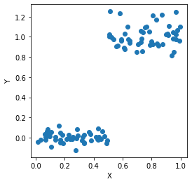

```python
from matplotlib import rc
import matplotlib.pyplot as plt

%matplotlib inline

rc("font", **{"family": "sans-serif", "sans-serif": ["DejaVu Sans"]})
rc("text", usetex=False)

plt.figure(figsize=(4, 4))
plt.xlabel("X")
plt.ylabel("Y")
plt.plot(X, Y, "o")
plt.savefig("decision_tree_single_split.pdf", dpi=600, bbox_inches="tight")
plt.show()
```

To train a decision tree means finding a function $\tilde{f}$:

$$ \tilde{f} = \sum_{i=0}^1 \alpha_i \mathbb{I}(\Omega_i) $$

where $\alpha_i$ are constant and $\Omega_i$ a half-space

$$ \Omega_0 = \left\{x |x \leq x_* \right\} $$$$ \Omega_1 = \left\{x |x > x_* \right\} $$

in such a way that

$$ \mathcal{L} = \|f - \alpha_0 \mathbb{I}(x\leq x_*) - \alpha_1 \mathbb{I}(x>x_*)\|_2 $$

is minimal. It is easy to proof that the constant better approximating in terms of $\mathbb{L}^2$ norm a set of values is the average of the values. Thus, in reality:

$$ \alpha_0 = \mathbb{E}_{\{x \leq x_*\}}(x) $$$$ \alpha_1 = \mathbb{E}_{\{x > x_*\}}(x) $$

Then the code is simply:

```python
L = np.zeros(len(X))
alpha_0 = np.zeros(len(X))
alpha_1 = np.zeros(len(X))
var_0 = np.zeros(len(X))
var_1 = np.zeros(len(X))

for i, x in enumerate(sorted(X[:-1])):
    alpha_0[i] = np.mean(Y[X <= x])
    alpha_1[i] = np.mean(Y[X > x])
    var_0[i] = np.var(Y[X <= x])
    var_1[i] = np.var(Y[X > x])
    L[i] = var_0[i] + var_1[i]
```

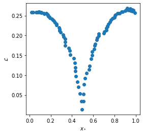

```python
rc("font", **{"family": "sans-serif", "sans-serif": ["DejaVu Sans"]})
rc("text", usetex=False)

plt.figure(figsize=(4, 4))
plt.xlabel("$x_*$")
plt.ylabel("$\mathcal{L}$")
plt.plot(X[:-1], L[:-1], "o")
plt.savefig("variance_sum.pdf", dpi=600, bbox_inches="tight")
plt.show()
```

```python
argmin = np.argmin(L[:-1])
print(argmin)
```

```
49
```

```python
print(X[argmin])
print(alpha_0[argmin])
print(alpha_1[argmin])
print(var_0[argmin])
print(var_1[argmin])
print(np.sqrt(var_0[argmin]))
print(np.sqrt(var_1[argmin]))
```

```
0.4931384144307994
0.00294933247103885
1.00663127011036
0.0021376086613367163
0.01124401780269872
0.04623428015376379
0.10603781307957422
```

Remark: the standard deviation is the square root of the MSE on each half space.

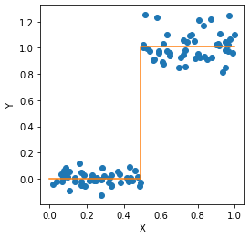

```python
rc("font", **{"family": "sans-serif", "sans-serif": ["DejaVu Sans"]})
rc("text", usetex=False)

plt.figure(figsize=(4, 4))
plt.xlabel("X")
plt.ylabel("Y")
plt.plot(X, Y, "o")
plt.step(
    [0, X[argmin], 1], [alpha_0[argmin], alpha_1[argmin], alpha_1[argmin]], where="post"
)
plt.savefig("decision_tree_single_split_found.pdf", dpi=600, bbox_inches="tight")
plt.show()
```

# A two variables example

Consider a different problem with two variables:

$$ X = \left\{(x_1, x_2) |x_1 \sim \mathcal{U}(0,1), x_2 \sim \mathcal{U}(0,1)\right\} $$

with response

$$ Y = \begin{cases} 10.0 & \left\{(x_1, x_2) \in X | x_1 \leq 0.5\right\}\\ 1.0 & \left\{(x_1, x_2) \in X | x_1 > 0.5, x_2 \leq 0.5\right\} \\ 0.0 & \left\{(x_1, x_2) \in X | x_1 > 0.5, x_2 > 0.5\right\} \\ \end{cases} $$

Graphically (code is written for readability and not for being Pythonic):

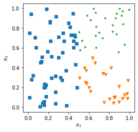

```python
np.random.seed(2020)
N = 100
x_1 = np.random.random(N)
x_2 = np.random.random(N)
Y = np.zeros(N)

for i in range(N):
    if x_1[i] <= 0.5:
        Y[i] = 10
    elif x_1[i] > 0.5 and x_2[i] <= 0.5:
        Y[i] = 1.0


rc("font", **{"family": "sans-serif", "sans-serif": ["DejaVu Sans"]})
rc("text", usetex=False)


plt.figure(figsize=(4, 4))
plt.xlim((-0.05, 1.05))
plt.ylim((-0.05, 1.05))
plt.xlabel("$x_1$")
plt.ylabel("$x_2$")
plt.plot(x_1[Y == 10], x_2[Y == 10], "s")
plt.plot(x_1[Y == 1], x_2[Y == 1], "v")
plt.plot(x_1[Y == 0], x_2[Y == 0], ".")
plt.savefig("decision_tree_two_variables.pdf", dpi=600, bbox_inches="tight")
plt.show()
```

Splitting on the first variable:

```python
L1 = np.zeros(len(x_1))
alpha_0 = np.zeros(len(x_1))
alpha_1 = np.zeros(len(x_1))
var_0 = np.zeros(len(x_1))
var_1 = np.zeros(len(x_1))

for i, x in enumerate(sorted(x_1)[:-1]):
    alpha_0[i] = np.mean(Y[x_1 <= x])
    alpha_1[i] = np.mean(Y[x_1 > x])
    var_0[i] = np.var(Y[x_1 <= x])
    var_1[i] = np.var(Y[x_1 > x])
    L1[i] = var_0[i] + var_1[i]
```

```python
argmin = np.argmin(L1[:-1])
x_1_s = sorted(x_1)[argmin]
print(x_1_s)
print(L1[argmin])
```

```
0.48281012636137444
0.24959999999999996
```

```python
L2 = np.zeros(len(x_2))
alpha_0 = np.zeros(len(x_2))
alpha_1 = np.zeros(len(x_2))
var_0 = np.zeros(len(x_2))
var_1 = np.zeros(len(x_2))

for i, x in enumerate(sorted(x_2)[:-1]):
    alpha_0[i] = np.mean(Y[x_2 <= x])
    alpha_1[i] = np.mean(Y[x_2 > x])
    var_0[i] = np.var(Y[x_2 <= x])
    var_1[i] = np.var(Y[x_2 > x])
    L2[i] = var_0[i] + var_1[i]
```

```python
argmin = np.argmin(L2[:-1])
x_2_s = sorted(x_2)[argmin]
print(sorted(x_2)[argmin])
print(L2[argmin])
```

```
0.9907878615970517
22.675551853394424
```

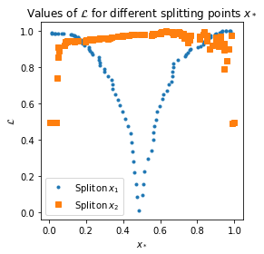

```python
rc("font", **{"family": "sans-serif", "sans-serif": ["DejaVu Sans"]})
rc("text", usetex=False)


plt.figure(figsize=(4, 4))
plt.xlabel("$x_*$")
plt.ylabel("$\mathcal{L}$")
plt.title("Values of $\mathcal{L}$ for different splitting points $x_*$")
plt.plot(sorted(x_1)[:-1], L1[:-1] / max(L1), ".", label="$\mathrm{Split\, on}\,x_1$")
plt.plot(sorted(x_2)[:-1], L2[:-1] / max(L2), "s", label="$\mathrm{Split\, on}\,x_2$")
plt.legend()
plt.savefig("variance_two_variables_sum.pdf", dpi=600, bbox_inches="tight")
plt.show()
```

```python
x_1_r = x_1[x_1 > x_1_s]
x_2_r = x_2[x_1 > x_1_s]
Y_r = Y[x_1 > x_1_s]
```

```python
L3 = np.zeros(len(x_1_r))
alpha_0 = np.zeros(len(x_1_r))
alpha_1 = np.zeros(len(x_1_r))
var_0 = np.zeros(len(x_1_r))
var_1 = np.zeros(len(x_1_r))

for i, x in enumerate(sorted(x_1_r)[:-1]):
    alpha_0[i] = np.mean(Y_r[x_1_r <= x])
    alpha_1[i] = np.mean(Y_r[x_1_r > x])
    var_0[i] = np.var(Y_r[x_1_r <= x])
    var_1[i] = np.var(Y_r[x_1_r > x])
    L3[i] = var_0[i] + var_1[i]
```

```python
argmin = np.argmin(L3[:-1])
x_1_r_s = sorted(x_1_r)[argmin]
print(x_1_r_s)
print(L3[argmin])
```

```
0.9862768288615988
0.2498958767180341
```

```python
L4 = np.zeros(len(x_1_r))
alpha_0 = np.zeros(len(x_1_r))
alpha_1 = np.zeros(len(x_1_r))
var_0 = np.zeros(len(x_1_r))
var_1 = np.zeros(len(x_1_r))

for i, x in enumerate(sorted(x_2_r)[:-1]):
    alpha_0[i] = np.mean(Y_r[x_2_r <= x])
    alpha_1[i] = np.mean(Y_r[x_2_r > x])
    var_0[i] = np.var(Y_r[x_2_r <= x])
    var_1[i] = np.var(Y_r[x_2_r > x])
    L4[i] = var_0[i] + var_1[i]
```

```python
argmin = np.argmin(L4[:-1])
x_2_r_s = sorted(x_2_r)[argmin]
print(x_2_r_s)
print(L4[argmin])
```

```
0.49497450782347385
0.0
```

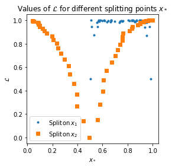

```python
rc("font", **{"family": "sans-serif", "sans-serif": ["DejaVu Sans"]})
rc("text", usetex=False)

plt.figure(figsize=(4, 4))
plt.xlabel("$x_*$")
plt.ylabel("$\mathcal{L}$")
plt.title("Values of $\mathcal{L}$ for different splitting points $x_*$")
plt.plot(
    sorted(x_1_r)[:-1], L3[:-1] / max(L3), ".", label="$\mathrm{Split\, on}\, x_1$"
)
plt.plot(
    sorted(x_2_r)[:-1], L4[:-1] / max(L4), "s", label="$\mathrm{Split\, on}\, x_2$"
)
plt.legend()
plt.savefig("variance_two_variables_sum_2.pdf", dpi=600, bbox_inches="tight")
plt.show()
```

Thus, split on the second variable for $x_2 \simeq 0.495$.

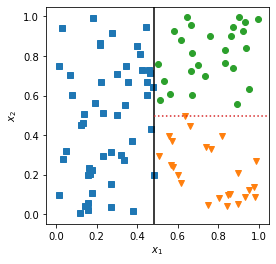

```python
rc("font", **{"family": "sans-serif", "sans-serif": ["DejaVu Sans"]})
rc("text", usetex=False)


plt.figure(figsize=(4, 4))
plt.xlim((-0.05, 1.05))
plt.ylim((-0.05, 1.05))
plt.xlabel("$x_1$")
plt.ylabel("$x_2$")
plt.plot(x_1[Y == 10], x_2[Y == 10], "s")
plt.plot(x_1[Y == 1], x_2[Y == 1], "v")
plt.plot(x_1[Y == 0], x_2[Y == 0], "o")
plt.axvline(x=x_1_s, linestyle="-", color="k")
plt.plot((x_1_s, 1.05), (x_2_r_s, x_2_r_s), linestyle=":")
plt.savefig("decision_tree_two_variables_first_split.pdf", dpi=600, bbox_inches="tight")
plt.show()
```

## A two variables example (revisited)

```python
import pandas as pd

df = pd.DataFrame({"$x_1$": x_1, "$x_2$": x_2,})
df.head()
```

|  | $x_1$ | $x_2$ |
| --- | --- | --- |
| 0 | 0.986277 | 0.269289 |
| 1 | 0.873392 | 0.944269 |
| 2 | 0.509746 | 0.295441 |
| 3 | 0.271836 | 0.151560 |
| 4 | 0.336919 | 0.272543 |

```python
from sklearn.tree import DecisionTreeRegressor

model = DecisionTreeRegressor(max_leaf_nodes=3).fit(df, Y)
print(model)
```

```
DecisionTreeRegressor(ccp_alpha=0.0, criterion='mse', max_depth=None,
                      max_features=None, max_leaf_nodes=3,
                      min_impurity_decrease=0.0, min_impurity_split=None,
                      min_samples_leaf=1, min_samples_split=2,
                      min_weight_fraction_leaf=0.0, presort='deprecated',
                      random_state=None, splitter='best')
```

Replacing the font for compatibility with plot_tree:

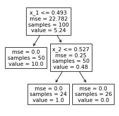

```python
from sklearn.tree import plot_tree

rc("font", **{"family": "sans-serif", "sans-serif": ["DejaVu Sans"]})
rc("text", usetex=False)

plt.figure(figsize=(4, 4))
plot_tree(model, filled=False, feature_names=["x_1", "x_2"])
plt.savefig("Decision_tree_sklearn.pdf", dpi=600, bbox_inches="tight")
plt.show()
```

```python
sorted(x_1)[49:51]
```

```
[0.48281012636137444, 0.5033670609602782]
```

```python
sorted(x_2_r)[23:25]
```

```
[0.49497450782347385, 0.5591430350510501]
```

```python
print(np.mean(sorted(x_1)[49:51]))
```

```
0.4930885936608263
```

```python
print(np.mean(sorted(x_2_r)[23:25]))
```

```
0.527058771437262
```

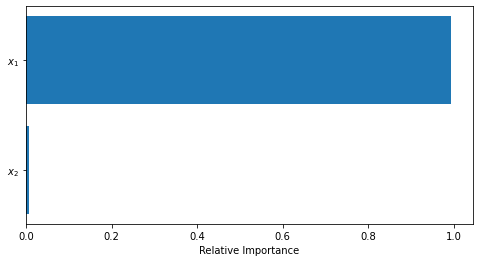

```python
features = df.columns
importances = model.feature_importances_
indices = np.argsort(importances)

rc("font", **{"family": "sans-serif", "sans-serif": ["DejaVu Sans"]})
rc("text", usetex=False)

plt.figure(figsize=(8, 4))
plt.barh(range(len(indices)), importances[indices], align="center")
plt.yticks(range(len(indices)), [features[i] for i in indices])
plt.xlabel("Relative Importance")
plt.savefig("scikit_model_1.pdf", dpi=600)
plt.show()
```

Print importances:

```python
print(importances)
```

```
[0.99452209 0.00547791]
```

It is calculated [like this](https://stackoverflow.com/questions/49170296/scikit-learn-feature-importance-calculation-in-decision-trees): for each split $s$ in the tree and calculate the weighted impurity decrease,

$$ \frac{N_t}{N}\left(I - \frac{N_{s,R}}{N_s}I_R- \frac{N_{s, L}}{N_s} I_L\right). $$

where $N$ is the total number of observations, $N_s$ is the number of observations at the current node, $N_{s,L}$ is the number of samples in the left child, and $N_{s,R}$ is the number of samples in the right child. $I$ represent the impurity (in our case, MSE), with the subscripts having the same meaning as before.

Thus for the first split, $x_1$ contribute with:

$$ \frac{100}{100} \times \left(22.782-\frac{50}{100}\times 0 --\frac{50}{100}\times 0.25 \right) \simeq 22.657 $$

For the second split, $x_2$ contribute with:

$$ \frac{50}{100} \times \left(0.25-\frac{25}{100}\times 0 --\frac{25}{100}\times 0.0 \right) \simeq 0.125 $$

Normalizing the total weighted variation to 1:

$$ \frac{22.657}{22.657+0.125}\simeq 0.995 $$$$ \frac{0.125}{22.657+0.125}\simeq 0.005 $$

Thus the column $x_1$ has an importance equal to $0.995$ for the model, while $x_2$ has an importance of 0.005. If the variables entered in different splits, the relative importance is summed.

# The importance of Feature Engineering

What we are trying with the decision tree is to approximate with step functions. Using the fact that a measurable function can be approximate with simple functions (i.e., with step functions) (Maderna-Soardi), the choice of approximating the function is formally correct. The problem is that the approximation may lead to a single observation per leaf, with the result that the generalization on unseen data would be unsatisfactory.

To overcome the problem, and possibly to make the models easier to interpret, additional features can be created to enrich the dataset and making the training of decision trees easier. Consider for example the problem:

$$ X = \left\{(x_1, x_2) |x_1 \sim \mathcal{U}(0,1), x_2 \sim \mathcal{U}(0,1)\right\} $$

and

$$ Y = \begin{cases} 1.0 & \left\{(x_1, x_2) \in X | x_1^2 +x_2^2 \leq 1\right\}\\ 0.0 & \left\{(x_1, x_2) \in X | x_1^2 +x_2^2 > 1\right\} \\ \end{cases} $$

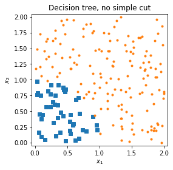

```python
np.random.seed(2020)
N = 200
x_1 = np.random.random(N) * 2
x_2 = np.random.random(N) * 2
df = pd.DataFrame({"x_1": x_1, "x_2": x_2})
Y = np.where(x_1 ** 2 + x_2 ** 2 <= 1, 1, 0)

rc("font", **{"family": "sans-serif", "sans-serif": ["DejaVu Sans"]})
rc("text", usetex=False)

plt.figure(figsize=(4, 4))
plt.xlim((-0.05, 2.05))
plt.ylim((-0.05, 2.05))
plt.xlabel("$x_1$")
plt.ylabel("$x_2$")
plt.title("Decision tree, no simple cut")
plt.plot(x_1[Y == 1], x_2[Y == 1], "s")
plt.plot(x_1[Y == 0], x_2[Y == 0], ".")
plt.savefig("decision_tree_polar_points.pdf", dpi=600, bbox_inches="tight")
plt.show()
```

A naive approach to the classification lead to reasonable results:

```python
model = DecisionTreeRegressor(max_leaf_nodes=3).fit(df, Y)
print(model)
```

```
DecisionTreeRegressor(ccp_alpha=0.0, criterion='mse', max_depth=None,
                      max_features=None, max_leaf_nodes=3,
                      min_impurity_decrease=0.0, min_impurity_split=None,
                      min_samples_leaf=1, min_samples_split=2,
                      min_weight_fraction_leaf=0.0, presort='deprecated',
                      random_state=None, splitter='best')
```

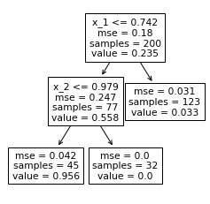

```python
rc("font", **{"family": "sans-serif", "sans-serif": ["DejaVu Sans"]})
rc("text", usetex=False)

plt.figure(figsize=(4, 4))
plot_tree(model, filled=False, feature_names=["x_1", "x_2"])
plt.savefig("Decision_tree_sklearn_polar.pdf", dpi=600, bbox_inches="tight")
plt.show()
```

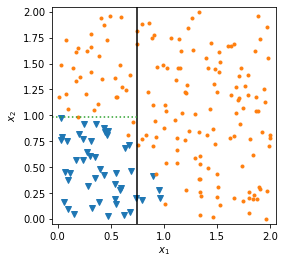

```python
rc("font", **{"family": "sans-serif", "sans-serif": ["DejaVu Sans"]})
rc("text", usetex=False)

plt.figure(figsize=(4, 4))
plt.xlim((-0.05, 2.05))
plt.ylim((-0.05, 2.05))
plt.xlabel("$x_1$")
plt.ylabel("$x_2$")
plt.plot(x_1[Y == 1], x_2[Y == 1], "v")
plt.plot(x_1[Y == 0], x_2[Y == 0], ".")
plt.axvline(x=0.742, color="k", linestyle="-")
plt.plot((-0.05, 0.742), (0.979, 0.979), linestyle=":")
plt.savefig("decision_tree_polar_manual.pdf", dpi=600, bbox_inches="tight")
plt.show()
```

If the following features are generated (basically, using polar coordinates assuming $x>0$):

$$ \rho = \sqrt{x_1^2 + x_2^2} $$$$ \vartheta = \arctan \left(\frac{y}{x}\right) $$

```python
df["rho"] = np.sqrt(df.x_1 ** 2 + df.x_2 ** 2)
df["theta"] = np.arctan(df.x_2 / df.x_1)
```

```python
df.head()
```

|  | x_1 | x_2 | rho | theta |
| --- | --- | --- | --- | --- |
| 0 | 1.972554 | 0.272456 | 1.991281 | 0.137255 |
| 1 | 1.746784 | 0.172684 | 1.755299 | 0.098538 |
| 2 | 1.019491 | 0.539177 | 1.153288 | 0.486475 |
| 3 | 0.543671 | 0.339722 | 0.641085 | 0.558503 |
| 4 | 0.673837 | 0.713459 | 0.981367 | 0.813951 |

```python
model = DecisionTreeRegressor(max_leaf_nodes=3).fit(df, Y)
print(model)
```

```
DecisionTreeRegressor(ccp_alpha=0.0, criterion='mse', max_depth=None,
                      max_features=None, max_leaf_nodes=3,
                      min_impurity_decrease=0.0, min_impurity_split=None,
                      min_samples_leaf=1, min_samples_split=2,
                      min_weight_fraction_leaf=0.0, presort='deprecated',
                      random_state=None, splitter='best')
```

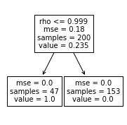

```python
rc("font", **{"family": "sans-serif", "sans-serif": ["DejaVu Sans"]})
rc("text", usetex=False)

plt.figure(figsize=(3, 3))
plot_tree(model, filled=False, feature_names=df.columns)
plt.savefig("Decision_tree_sklearn_polar.pdf", dpi=600, bbox_inches="tight")
plt.show()
```

That is, a perfect score and simpler tree.

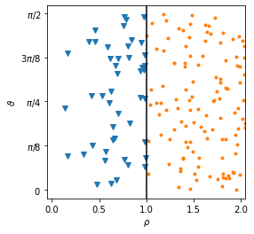

```python
rc("font", **{"family": "sans-serif", "sans-serif": ["DejaVu Sans"]})
rc("text", usetex=False)

plt.figure(figsize=(4, 4))
plt.xlim((-0.05, 2.05))
plt.xlabel("$\\rho$")
plt.ylabel("$\\vartheta$")
plt.yticks(
    ticks=[0, np.pi / 8, np.pi / 4.0, np.pi * 3.0 / 8, np.pi / 2.0],
    labels=["$0$", "$\pi/8$", "$\pi/4$", "$3\pi/8$", "$\pi/2$"],
)
# plt.title("Decision tree with polar coordinates")
plt.plot(df.rho[Y == 1], df.theta[Y == 1], "v")
plt.plot(df.rho[Y == 0], df.theta[Y == 0], ".")
plt.axvline(x=0.999, color="k")
plt.savefig("decision_tree_polar_ref.pdf", dpi=600, bbox_inches="tight")
plt.show()
```

# Nuclear Mass Models

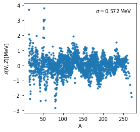

```python
import pandas as pd


f = open("residuals.dat", "r")
content = f.readlines()
f.close()
data = {
    "A": [int(i[9:13]) for i in content[1:]],
    "N": [int(i[21:24]) for i in content[1:]],
    "Z": [int(i[33:36]) for i in content[1:]],
    "Residual (MEV)": [float(i[36:].strip()) for i in content[1:]],
}

ale = pd.DataFrame(data)

rc("font", **{"family": "sans-serif", "sans-serif": ["DejaVu Sans"]})
rc("text", usetex=False)


plt.figure(figsize=(4, 4))
plt.xlabel("A")
plt.ylabel("$\mathcal{E}(N, Z)$[MeV]")
plt.plot(ale.A, ale["Residual (MEV)"], ".", label="$\sigma=0.572\,\mathrm{MeV}$")
plt.legend(frameon=False, markerscale=0)
plt.savefig("residual_dz10.pdf", dpi=600, bbox_inches="tight")
plt.show()
```

[figure not shown]

```python
f = open("residuals_liquid_drop.dat", "r")
content = f.readlines()
f.close()
data = {
    "A": [int(i[9:13]) for i in content[1:]],
    "N": [int(i[21:24]) for i in content[1:]],
    "Z": [int(i[33:36]) for i in content[1:]],
    "Residual (MEV)": [float(i[36:].strip()) for i in content[1:]],
}

goccia = pd.DataFrame(data)


rc("font", **{"family": "sans-serif", "sans-serif": ["DejaVu Sans"]})
rc("text", usetex=False)

plt.figure(figsize=(4, 4))
plt.xlabel("A")
plt.ylabel("$\mathcal{E}(N, Z)$[MeV]")
# plt.title("Residuals for Liquid Model")
plt.plot(goccia.A, goccia["Residual (MEV)"], ".", label="$\sigma=2.937\,\mathrm{MeV}$")
plt.legend(frameon=False, markerscale=0)
plt.savefig("residual_liquid_drop.pdf", dpi=600, bbox_inches="tight")
plt.show()
```

## Liquid Drop

The first step is to prepare data to be comma separate format (it is easier to handle for building Machine Learning models). Create a CSV file:

```python
import pandas as pd

f = open("residuals_liquid_drop.dat", "r")
content = f.readlines()
f.close()
data = {
    "A": [int(i[9:13]) for i in content[1:]],
    "N": [int(i[21:24]) for i in content[1:]],
    "Z": [int(i[33:36]) for i in content[1:]],
    "Residual (MEV)": [float(i[36:].strip()) for i in content[1:]],
}

train = pd.DataFrame(data)
train.head()
```

|  | A | N | Z | Residual (MEV) |
| --- | --- | --- | --- | --- |
| 0 | 15 | 10 | 5 | 1.136133 |
| 1 | 15 | 9 | 6 | 0.651858 |
| 2 | 15 | 8 | 7 | 0.254488 |
| 3 | 15 | 7 | 8 | 0.166684 |
| 4 | 15 | 6 | 9 | 2.052728 |

```python
import numpy as np

print(np.mean(train["Residual (MEV)"]))
print(np.std(train["Residual (MEV)"]))
```

```
0.002690832231143599
0.5719458916369262
```

```python
from hyperopt import hp
from hyperopt import fmin
from hyperopt import tpe
from hyperopt import STATUS_OK
from hyperopt import Trials
from sklearn.tree import DecisionTreeRegressor
from sklearn.model_selection import cross_val_score


np.random.seed(2020)
Y = train["Residual (MEV)"].ravel()
X = train.drop(["Residual (MEV)"], axis=1)
space = {
    "max_leaf_nodes": hp.choice("max_leaf_nodes", list(range(2, 501))),
}


def objective(space):
    model = DecisionTreeRegressor(
        random_state=2020, max_leaf_nodes=int(space["max_leaf_nodes"])
    )
    mse = cross_val_score(model, X, Y, cv=3, scoring="neg_mean_squared_error")
    return {
        "loss": -mse.mean(),
        "std": mse.std(),
        "status": STATUS_OK,
    }


trials = Trials()
best = fmin(fn=objective, space=space, algo=tpe.suggest, max_evals=499, trials=trials)
list(range(2, 501))[best["max_leaf_nodes"]]
```

```
5
```

```python
list(range(2, 501))[best["max_leaf_nodes"]]
```

```
5
```

All the values explored and the performance of the models are saved in a new data frame:

```python
performance = pd.DataFrame(
    {"max_leaf_nodes": [list(range(2, 501))[i] for i in trials.vals["max_leaf_nodes"]]}
)
performance["MSE_mean"] = [i["loss"] for i in trials.results]
performance["MSE_std"] = [i["std"] for i in trials.results]
performance = performance[["MSE_mean", "MSE_std", "max_leaf_nodes"]]
performance = performance.sort_values(by="MSE_mean")
performance.drop_duplicates(inplace=True)
performance.head(n=10)
```

|  | MSE_mean | MSE_std | max_leaf_nodes |
| --- | --- | --- | --- |
| 290 | 0.345637 | 0.119345 | 5 |
| 422 | 0.346113 | 0.119010 | 3 |
| 261 | 0.350029 | 0.116367 | 7 |
| 473 | 0.350708 | 0.115930 | 6 |
| 110 | 0.351063 | 0.115703 | 4 |
| 66 | 0.352661 | 0.114400 | 9 |
| 210 | 0.355697 | 0.123403 | 46 |
| 381 | 0.356907 | 0.122686 | 49 |
| 137 | 0.356907 | 0.122686 | 48 |
| 452 | 0.356907 | 0.122686 | 55 |

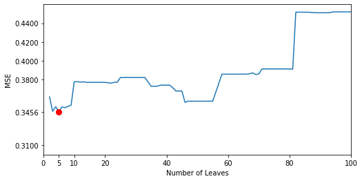

```python
rc("font", **{"family": "sans-serif", "sans-serif": ["DejaVu Sans"]})
rc("text", usetex=False)
temp = performance.sort_values("max_leaf_nodes")

plt.figure(figsize=(8, 4))
plt.xticks((0, 5, 10, 20, 40, 60, 80, 100))
plt.yticks((0.31, 0.345637, 0.38, 0.4, 0.42, 0.44))
plt.xlabel("Number of Leaves")
plt.ylabel("MSE")
plt.xlim((0, 100))
plt.ylim((0.3, 0.460))
plt.plot(temp.max_leaf_nodes, temp.MSE_mean)
plt.plot(5, 0.345637, "ro", markersize=8)
plt.savefig("MSE_liquid_drop.pdf", dpi=600, bbox_inches="tight")
plt.show()
```

Performance on unseen data:

```python
print(list(np.sqrt(performance["MSE_mean"]))[0])
```

```
0.587908919693947
```

Retraining on all data:

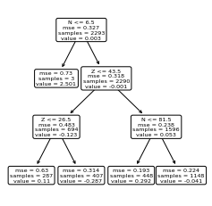

```python
from sklearn.tree import plot_tree

rc("font", **{"family": "sans-serif", "sans-serif": ["DejaVu Sans"]})
rc("text", usetex=False)


model = DecisionTreeRegressor(
    random_state=2019, max_leaf_nodes=list(range(2, 501))[best["max_leaf_nodes"]]
).fit(X, Y)
plt.figure(figsize=(4, 4))
plot_tree(model, filled=False, feature_names=X.columns, rounded=True)
plt.savefig("tree1.pdf", dpi=600, bbox_inches="tight")
plt.show()
```

The training error is:

```python
print(np.sqrt(np.mean((model.predict(X) - Y) ** 2)))
```

```
0.5342253839655683
```

Adding Features to the model (Feature Engineering):

```python
X["Z_even"] = [i % 2 for i in X["Z"]]
X["N_even"] = [i % 2 for i in X["N"]]
X["N_Z"] = X["N"] - X["Z"]
X["N_on_Z"] = X["N"] / X["Z"]
X["Z_A"] = X["Z"] / X["A"]
X["N_A"] = X["N"] / X["A"]

space = {
    "max_leaf_nodes": hp.choice("max_leaf_nodes", list(range(2, 501))),
}


def objective(space):
    model = DecisionTreeRegressor(
        random_state=2019, max_leaf_nodes=int(space["max_leaf_nodes"])
    )
    mse = cross_val_score(model, X, Y, cv=3, scoring="neg_mean_squared_error")
    return {
        "loss": -mse.mean(),
        "std": mse.std(),
        "status": STATUS_OK,
    }


trials = Trials()
best = fmin(fn=objective, space=space, algo=tpe.suggest, max_evals=501, trials=trials)
list(range(2, 501))[best["max_leaf_nodes"]]


performance = pd.DataFrame(
    {"max_leaf_nodes": [list(range(2, 501))[i] for i in trials.vals["max_leaf_nodes"]]}
)
performance["MSE_mean"] = [i["loss"] for i in trials.results]
performance["MSE_std"] = [i["std"] for i in trials.results]
performance = performance[["MSE_mean", "MSE_std", "max_leaf_nodes"]]
performance = performance.sort_values(by="MSE_mean")
performance.drop_duplicates(inplace=True)
performance.head(n=10)
```

|  | MSE_mean | MSE_std | max_leaf_nodes |
| --- | --- | --- | --- |
| 410 | 0.325608 | 0.150315 | 13 |
| 390 | 0.325608 | 0.150315 | 12 |
| 453 | 0.340072 | 0.140624 | 14 |
| 104 | 0.340072 | 0.140624 | 15 |
| 335 | 0.340072 | 0.140624 | 16 |
| 273 | 0.341245 | 0.139865 | 18 |
| 94 | 0.341245 | 0.139865 | 17 |
| 350 | 0.348728 | 0.135844 | 24 |
| 297 | 0.348728 | 0.135844 | 21 |
| 189 | 0.348728 | 0.135844 | 26 |

Performance on unseen data:

```python
print(list(np.sqrt(performance["MSE_mean"]))[0])
```

```
0.5706204809117935
```

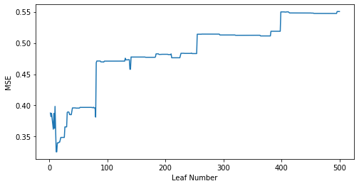

```python
temp = performance.sort_values("max_leaf_nodes")

rc("font", **{"family": "sans-serif", "sans-serif": ["DejaVu Sans"]})
rc("text", usetex=False)

plt.figure(figsize=(8, 4))
plt.xlabel("Leaf Number")
plt.ylabel("MSE")
plt.plot(temp.max_leaf_nodes, temp.MSE_mean)
plt.show()
```

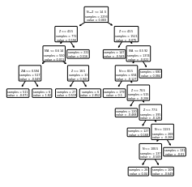

```python
rc("font", **{"family": "sans-serif", "sans-serif": ["DejaVu Sans"]})
rc("text", usetex=False)

mapper = {
    "A": "$\mathrm{A}$",
    "N": "$\mathrm{N}$",
    "Z": "$\mathrm{Z}$",
    "Z_even": "$\mathrm{Z}_{\mathrm{even}}$",
    "N_even": "$\mathrm{N}_{\mathrm{even}}$",
    "N_Z": "$\mathrm{N-Z}$",
    "N_on_Z": "$\mathrm{N/Z}$",
    "Z_A": "$\mathrm{Z/A}$",
    "N_A": "$\mathrm{N/A}$",
}
model = DecisionTreeRegressor(
    random_state=2019, max_leaf_nodes=list(range(2, 501))[best["max_leaf_nodes"]]
).fit(X, Y)
plt.figure(figsize=(4, 4))
plot_tree(
    model,
    filled=False,
    feature_names=[mapper[i] for i in list(X.columns)],
    rounded=True,
    impurity=False,
)
plt.savefig("tree2.pdf", dpi=600, bbox_inches="tight")
plt.show()
```

The training error:

```python
print(np.sqrt(np.mean((model.predict(X) - Y) ** 2)))
```

```
0.4586648936705849
```

For feature importance, the [Stackoverflow post](https://stackoverflow.com/questions/44101458/random-forest-feature-importance-chart-using-python) was used as a reference

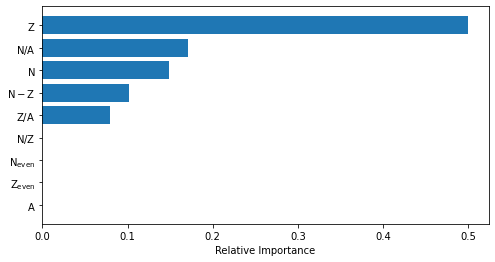

```python
features = X.columns
importances = model.feature_importances_
indices = np.argsort(importances)

rc("font", **{"family": "sans-serif", "sans-serif": ["DejaVu Sans"]})
rc("text", usetex=False)

plt.figure(figsize=(8, 4))
plt.barh(range(len(indices)), importances[indices], align="center")
plt.yticks(range(len(indices)), [mapper[features[i]] for i in indices])
plt.xlabel("Relative Importance")
plt.savefig("tree3.pdf", dpi=600, bbox_inches="tight")
plt.show()
```

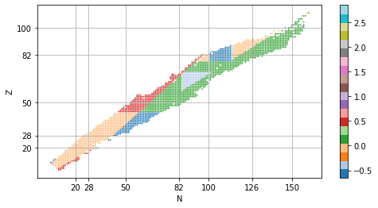

```python
corrections = pd.DataFrame({"x": X.N, "y": X.Z, "c": model.predict(X)})

rc("font", **{"family": "sans-serif", "sans-serif": ["DejaVu Sans"]})
rc("text", usetex=False)

plt.figure(figsize=(8, 4))
plt.scatter(corrections.x, corrections.y, c=corrections.c, s=0.5, cmap=plt.cm.tab20)
plt.xlabel("N")
plt.ylabel("Z")
plt.xticks([20, 28, 50, 82, 100, 126, 150])
plt.yticks([20, 28, 50, 82, 100])
plt.grid()
plt.colorbar()
plt.savefig("corrections_chart_liquid_drop.pdf", dpi=1200, bbox_inches="tight")
plt.show()
```

## DZ10

```python
import pandas as pd

f = open("residuals.dat", "r")
content = f.readlines()
f.close()

data = {
    "A": [int(i[9:13]) for i in content[1:]],
    "N": [int(i[21:24]) for i in content[1:]],
    "Z": [int(i[33:36]) for i in content[1:]],
    "Residual (MEV)": [float(i[36:].strip()) for i in content[1:]],
}

train = pd.DataFrame(data)
train.head()
```

|  | A | N | Z | Residual (MEV) |
| --- | --- | --- | --- | --- |
| 0 | 15 | 10 | 5 | 1.136133 |
| 1 | 15 | 9 | 6 | 0.651858 |
| 2 | 15 | 8 | 7 | 0.254488 |
| 3 | 15 | 7 | 8 | 0.166684 |
| 4 | 15 | 6 | 9 | 2.052728 |

```python
import numpy as np

print(np.mean(train["Residual (MEV)"]))
print(np.std(train["Residual (MEV)"]))
```

```
0.002690832231143599
0.5719458916369262
```

```python
from hyperopt import hp
from hyperopt import fmin
from hyperopt import tpe
from hyperopt import STATUS_OK
from hyperopt import Trials
from sklearn.tree import DecisionTreeRegressor
from sklearn.model_selection import cross_val_score


np.random.seed(2020)
Y = train["Residual (MEV)"].ravel()
X = train.drop(["Residual (MEV)"], axis=1)
X["Z_even"] = [i % 2 for i in X["Z"]]
X["N_even"] = [i % 2 for i in X["N"]]
X["N_Z"] = X["N"] - X["Z"]
X["N_on_Z"] = X["N"] / X["Z"]
X["Z_A"] = X["Z"] / X["A"]
X["N_A"] = X["N"] / X["A"]

space = {
    "max_leaf_nodes": hp.choice("max_leaf_nodes", list(range(2, 501))),
}


def objective(space):
    model = DecisionTreeRegressor(
        random_state=2020, max_leaf_nodes=int(space["max_leaf_nodes"])
    )
    mse = cross_val_score(model, X, Y, cv=3, scoring="neg_mean_squared_error")
    return {
        "loss": -mse.mean(),
        "std": mse.std(),
        "status": STATUS_OK,
    }


trials = Trials()
best = fmin(fn=objective, space=space, algo=tpe.suggest, max_evals=499, trials=trials)
print(list(range(2, 501))[best["max_leaf_nodes"]])


performance = pd.DataFrame(
    {"max_leaf_nodes": [list(range(2, 501))[i] for i in trials.vals["max_leaf_nodes"]]}
)
performance["MSE_mean"] = [i["loss"] for i in trials.results]
performance["MSE_std"] = [i["std"] for i in trials.results]
performance = performance[["MSE_mean", "MSE_std", "max_leaf_nodes"]]
performance = performance.sort_values(by="MSE_mean")
performance.drop_duplicates(inplace=True)
performance.head(n=10)
```

```
11
```

|  | MSE_mean | MSE_std | max_leaf_nodes |
| --- | --- | --- | --- |
| 242 | 0.323782 | 0.151691 | 11 |
| 344 | 0.325608 | 0.150315 | 12 |
| 301 | 0.325608 | 0.150315 | 13 |
| 114 | 0.340072 | 0.140624 | 15 |
| 219 | 0.340072 | 0.140624 | 16 |
| 304 | 0.340072 | 0.140624 | 14 |
| 45 | 0.341245 | 0.139865 | 17 |
| 44 | 0.341245 | 0.139865 | 18 |
| 456 | 0.348728 | 0.135844 | 21 |
| 362 | 0.348728 | 0.135844 | 26 |

Error on unseen data:

```python
print(list(np.sqrt(performance["MSE_mean"]))[0])
```

```
0.569018079169662
```

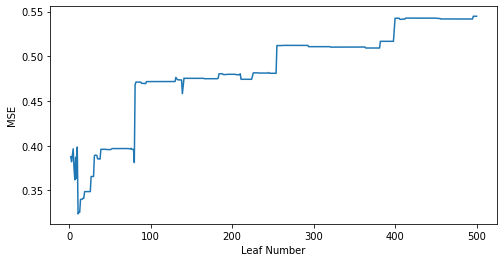

```python
temp = performance.sort_values("max_leaf_nodes")

rc("font", **{"family": "sans-serif", "sans-serif": ["DejaVu Sans"]})
rc("text", usetex=False)

plt.figure(figsize=(8, 4))
plt.xlabel("Leaf Number")
plt.ylabel("MSE")
plt.plot(temp.max_leaf_nodes, temp.MSE_mean)
plt.show()
```

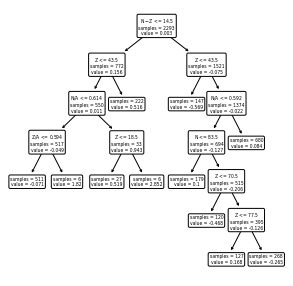

```python
rc("font", **{"family": "sans-serif", "sans-serif": ["DejaVu Sans"]})
rc("text", usetex=False)

model = DecisionTreeRegressor(
    random_state=2019, max_leaf_nodes=list(range(2, 501))[best["max_leaf_nodes"]]
).fit(X, Y)
plt.figure(figsize=(5, 5))
plot_tree(
    model,
    filled=False,
    feature_names=[mapper[i] for i in list(X.columns)],
    rounded=True,
    impurity=False,
)
plt.savefig("tree4.pdf", dpi=600, bbox_inches="tight")
plt.show()
```

Training error:

```python
print(np.sqrt(np.mean((model.predict(X) - Y) ** 2)))
```

```
0.4714311373914842
```

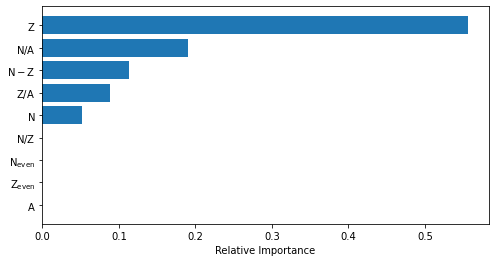

```python
features = X.columns
importances = model.feature_importances_
indices = np.argsort(importances)

rc("font", **{"family": "sans-serif", "sans-serif": ["DejaVu Sans"]})
rc("text", usetex=False)

plt.figure(figsize=(8, 4))
plt.barh(range(len(indices)), importances[indices], align="center")
plt.yticks(range(len(indices)), [mapper[features[i]] for i in indices])
plt.xlabel("Relative Importance")
plt.savefig("tree5.pdf", dpi=600, bbox_inches="tight")
plt.show()
```

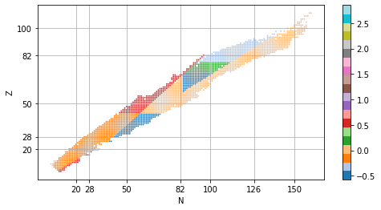

```python
corrections = pd.DataFrame({"x": X.N, "y": X.Z, "c": model.predict(X)})

rc("font", **{"family": "sans-serif", "sans-serif": ["DejaVu Sans"]})
rc("text", usetex=False)

plt.figure(figsize=(8, 4))
plt.scatter(corrections.x, corrections.y, c=corrections.c, s=0.5, cmap=plt.cm.tab20)
plt.xlabel("N")
plt.ylabel("Z")
plt.xticks([20, 28, 50, 82, 100, 126, 150])
plt.yticks([20, 28, 50, 82, 100])
plt.grid()
plt.colorbar()
plt.savefig("corrections_chart_dz10.pdf", dpi=1200, bbox_inches="tight")
plt.show()
```

## DZ10: Residues Plots

```python
residues_dz10_with_tree = model.predict(X) - Y
residues_dz10_without_tree = Y
```

Using and adopting [the Stackoverflow post](https://stackoverflow.com/questions/20011122/fitting-a-normal-distribution-to-1d-data/20012350):

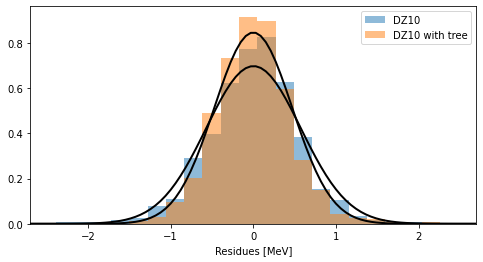

```python
from scipy.stats import norm

rc("font", **{"family": "sans-serif", "sans-serif": ["DejaVu Sans"]})
rc("text", usetex=False)

plt.figure(figsize=(8, 4))
plt.xlim((-2.7, 2.7))
plt.xlabel("Residues [MeV]")
n, bins, patches = plt.hist(
    residues_dz10_without_tree, bins=30, alpha=0.5, density=True, label="DZ10"
)
p = norm.pdf(
    np.linspace(-3, 3, 100),
    np.mean(residues_dz10_without_tree),
    np.std(residues_dz10_without_tree),
)
plt.plot(np.linspace(-3, 3, 100), p, "k", linewidth=2)
plt.hist(
    residues_dz10_with_tree, bins=bins, alpha=0.5, density=True, label="DZ10 with tree"
)
p = norm.pdf(
    np.linspace(-3, 3, 100),
    np.mean(residues_dz10_with_tree),
    np.std(residues_dz10_with_tree),
)
plt.plot(np.linspace(-3, 3, 100), p, "k", linewidth=2)
plt.legend()
plt.show()
```

To match the fit color to the default, the [color names are printed](https://stackoverflow.com/questions/42086276/get-default-line-colour-cycle):

```python
print(plt.rcParams["axes.prop_cycle"].by_key()["color"])
```

```
['#1f77b4', '#ff7f0e', '#2ca02c', '#d62728', '#9467bd', '#8c564b', '#e377c2', '#7f7f7f', '#bcbd22', '#17becf']
```

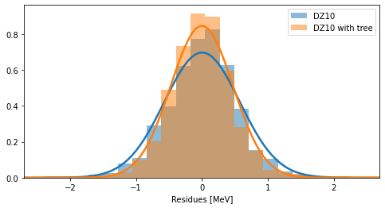

```python
rc("font", **{"family": "sans-serif", "sans-serif": ["DejaVu Sans"]})
rc("text", usetex=False)

plt.figure(figsize=(8, 4))
plt.xlim((-2.7, 2.7))
plt.xlabel("Residues [MeV]")
n, bins, patches = plt.hist(
    residues_dz10_without_tree, bins=30, alpha=0.5, density=True, label="DZ10"
)
p = norm.pdf(
    np.linspace(-3, 3, 100),
    np.mean(residues_dz10_without_tree),
    np.std(residues_dz10_without_tree),
)
plt.plot(np.linspace(-3, 3, 100), p, "#1f77b4", linewidth=2.5)
plt.hist(
    residues_dz10_with_tree, bins=bins, alpha=0.5, density=True, label="DZ10 with tree"
)
p = norm.pdf(
    np.linspace(-3, 3, 100),
    np.mean(residues_dz10_with_tree),
    np.std(residues_dz10_with_tree),
)
plt.plot(np.linspace(-3, 3, 100), p, "#ff7f0e", linewidth=2.5)
plt.legend()
plt.savefig("histo.pdf", dpi=600, bbox_inches="tight")
plt.show()
```